# Topic Modelling with COVID-19 Articles

Homework 4

Blarry Wang, Ihsan Kahveci, Megan Erickson, Morgan Wack, Nicholas Wittstock

April 29, 2020

```r
library(quanteda)
library(tidyverse)
library(topicmodels)
library(stm)
```

# Text Preparation

## Importing the data

```r
setwd("~/Desktop/POLS559/hw4")
data  <- read.csv("./COVIDarticletitles.csv",
                  na.strings = "", stringsAsFactors = FALSE)
```

```r
data %>% str()
```

```
## 'data.frame':    57378 obs. of  2170 variables:
##  $ title  : chr  "Sequence requirements for RNA strand transfer during nidovirus discontinuous subgenomic RNA synthesis" "Crystal structure of murine sCEACAM1a[1,4]: a coronavirus receptor in the CEA family" "Synthesis of a novel hepatitis C virus protein by ribosomal frameshift" "Structure of co…
##  $ X      : logi  NA NA NA NA NA NA ...
##  $ authors: chr  "Pasternak, Alexander O.; van den Born, Erwin; Spaan, Willy J.M.; Snijder, Eric J." "Tan, Kemin; Zelus, Bruce D.; Meijers, Rob; Liu, Jin-huan; Bergelson, Jeffrey M.; Duke, Norma; Zhang, Rongguang;"| __truncated__ "Xu, Zhenming; Choi, Jinah; Yen, T.S.Benedict; Lu, Wen; Strohecker,…
##  $ journal: chr  "The EMBO Journal" "The EMBO Journal" "EMBO J" "The EMBO Journal" ...
##  $ doi    : chr  "10.1093/emboj/20.24.7220" "10.1093/emboj/21.9.2076" "10.1093/emboj/20.14.3840" "10.1093/emboj/cdf327" ...
##  $ X.1    : chr  NA NA NA NA ...
##  $ X.2    : chr  NA NA NA NA ...
##  $ X.3    : chr  NA NA NA NA ...
##  $ X.4    : chr  NA NA NA NA ...
##  $ X.5    : chr  NA NA NA NA ...
##  $ X.6    : chr  NA NA NA NA ...
##  $ X.7    : chr  NA NA NA NA ...
##  $ X.8    : chr  NA NA NA NA ...
##  $ X.9    : chr  NA NA NA NA ...
```

[output cut: 86 more lines]

There are many authors for each text and they don’t seem that they are overlapping. So, we don’t think they are not useful as metadata.

```r
data_sub <- data %>% select(title, journal)
data_sub %>% glimpse()
```

```
## Observations: 57,378
## Variables: 2
## $ title   <chr> "Sequence requirements for RNA strand transfer during nidovir…
## $ journal <chr> "The EMBO Journal", "The EMBO Journal", "EMBO J", "The EMBO J…
```

## Creating the corpus

```r
corpus <- corpus(data_sub, text_field = "title")
corpus %>% summary()
```

```
## Corpus consisting of 57378 documents, showing 100 documents:
##
##     Text Types Tokens Sentences                            journal
##    text1    11     12         1                   The EMBO Journal
##    text2    16     16         1                   The EMBO Journal
##    text3    11     11         1                             EMBO J
##    text4    15     16         1                   The EMBO Journal
##    text5     9      9         1                   The EMBO Journal
##    text6    14     15         1                  BMC Public Health
##    text7     6      6         1                        Genome Biol
##    text8    15     15         1                   The EMBO Journal
##    text9     9     11         1                        Genome Biol
##   text10    12     12         1                   The EMBO Journal
##   text11    12     12         1                      BMC Med Genet
##   text12     8      8         1                     BMC Infect Dis
##   text13    10     10         1                      BMC Microbiol
##   text14    13     13         1                 BMC Bioinformatics
##   text15     8      8         1                          PLoS Biol
##   text16    20     22         1                    BMC Struct Biol
##   text17    16     17         1                     Environ Health
##   text18     6      6         1                          PLoS Biol
##   text19    11     11         1                   The EMBO Journal
##   text20    11     11         1                 Biol Proced Online
##   text21     9      9         1                   The EMBO Journal
##   text22    16     16         1                 Int J Health Geogr
##   text23    15     16         1                 Int J Health Geogr
##   text24    16     16         1                          Crit Care
##   text25    14     18         1                          Crit Care
##   text26    11     11         1                          Crit Care
##   text27    12     13         1      Ann Clin Microbiol Antimicrob
##   text28     7      7         1                 BMC Bioinformatics
##   text29    15     15         1                 BMC Bioinformatics
##   text30    11     11         1                      BMC Evol Biol
##   text31    21     21         1                          Crit Care
##   text32    10     10         1                 BMC Bioinformatics
##   text33     7      8         1                     BMC Infect Dis
##   text34    12     12         1                      BMC Cell Biol
##   text35    14     15         1                     BMC Infect Dis
##   text36    15     15         1                     BMC Infect Dis
##   text37    16     16         1                  BMC Public Health
```

[output cut: 48 more lines]

```
##   text86     8      8         1                   The EMBO Journal
##   text87     9      9         1                 BMC Bioinformatics
##   text88    16     16         1                       BMC Genomics
##   text89    12     13         1                   J Inflamm (Lond)
##   text90    14     15         1                         Respir Res
##   text91    22     30         1                  Nucleic Acids Res
##   text92    11     11         1                  Nucleic Acids Res
##   text93    13     13         1           BMC Med Inform Decis Mak
##   text94    14     15         1                   The EMBO Journal
##   text95    16     20         1                             EMBO J
##   text96    17     19         1                          Crit Care
##   text97    11     11         1                        Genome Biol
##   text98     9     10         1                            Virol J
##   text99     8      8         1                           PLoS Med
##  text100    18     18         1                  Nucleic Acids Res
```

```r
texts(corpus)[1:5]
```

```
##                                                                                                                text1
##              "Sequence requirements for RNA strand transfer during nidovirus discontinuous subgenomic RNA synthesis"
##                                                                                                                text2
##                               "Crystal structure of murine sCEACAM1a[1,4]: a coronavirus receptor in the CEA family"
##                                                                                                                text3
##                                             "Synthesis of a novel hepatitis C virus protein by ribosomal frameshift"
##                                                                                                                text4
## "Structure of coronavirus main proteinase reveals combination of a chymotrypsin fold with an extra α-helical domain"
##                                                                                                                text5
##                                    "Discontinuous and non-discontinuous subgenomic RNA transcription in a nidovirus"
```

# Document Frequency Matrices

we created customized stopwords

```r
stops = c(stopwords("english"), "coronavirus", "covid-19", "virus", "diseas")
```

creating a quanteda dfm object from corpus:

```r
quantdfm <- corpus %>%
  dfm(remove_punct = TRUE, remove_numbers = TRUE, stem = TRUE) %>%
  dfm(remove=stops) #it is important to remove stopwords after stemming
```

Removing the extreme terms from the matrix:

```r
quantdfm <- dfm_trim(quantdfm, min_termfreq = 0.00001, termfreq_type = "prop",
         max_docfreq = 0.2, docfreq_type = "prop", verbose = TRUE)
```

```
## Removing features occurring:
```

```
##   - fewer than 4.94428 times: 29,218
```

```
##   Total features removed: 29,218 (80.2%).
```

Removes empty cases:

```r
empty_docs <- which((ntoken(quantdfm) > 0) == F) #indices of omitted docs
quantdfm <- dfm_subset(quantdfm, ntoken(quantdfm) > 0)
```

# Model Fit: LDA

LDA model with 10 topics

```r
model_LDA <- LDA(convert(quantdfm, to = "topicmodels"), k = 10,
             control=list(seed=57))
get_terms(model_LDA, 10)
```

```
##       Topic 1       Topic 2       Topic 3       Topic 4       Topic 5
##  [1,] "respiratori" "respiratori" "viral"       "rna"         "human"
##  [2,] "viral"       "syndrom"     "infect"      "studi"       "respiratori"
##  [3,] "detect"      "protein"     "cell"        "respiratori" "viral"
##  [4,] "influenza"   "detect"      "porcin"      "human"       "infecti"
##  [5,] "infect"      "infect"      "health"      "sever"       "emerg"
##  [6,] "analysi"     "influenza"   "epidem"      "pandem"      "analysi"
##  [7,] "use"         "acut"        "chapter"     "protein"     "infect"
##  [8,] "effect"      "health"      "de"          "acut"        "clinic"
##  [9,] "human"       "express"     "respiratori" "cell"        "children"
## [10,] "structur"    "studi"       "activ"       "use"         "vaccin"
##       Topic 6       Topic 7       Topic 8       Topic 9       Topic 10
##  [1,] "respiratori" "infect"      "infect"      "infect"      "infect"
##  [2,] "protein"     "cell"        "cell"        "respiratori" "protein"
##  [3,] "influenza"   "respiratori" "human"       "syndrom"     "respons"
##  [4,] "infecti"     "express"     "infecti"     "respons"     "emerg"
##  [5,] "infect"      "outbreak"    "novel"       "viral"       "syndrom"
##  [6,] "system"      "novel"       "respiratori" "human"       "patient"
##  [7,] "children"    "clinic"      "acut"        "protein"     "middl"
##  [8,] "vaccin"      "sar"         "system"      "influenza"   "sever"
##  [9,] "detect"      "pathogen"    "control"     "cell"        "east"
## [10,] "pandem"      "human"       "effect"      "analysi"     "use"
```

Running another model without custom stopwords and compare it to original model:

```r
quantdfm2 <- corpus %>%
  dfm(remove_punct = TRUE, remove_numbers = TRUE, stem = TRUE,
      remove = stopwords("english"))

quantdfm2 <- dfm_trim(quantdfm2, min_termfreq = 0.00001, termfreq_type = "prop",
         max_docfreq = 0.2, docfreq_type = "prop", verbose = TRUE)
```

```
## Removing features occurring:
```

```
##   - fewer than 5.18147 times: 30,103
```

```
##   Total features removed: 30,103 (82.6%).
```

```r
quantdfm2 <- dfm_subset(quantdfm2, ntoken(quantdfm2) > 0)
```

```r
model_LDA2 <- LDA(convert(quantdfm2, to = "topicmodels"), k = 10,
             control=list(seed=57))
get_terms(model_LDA2, 10)
```

```
##       Topic 1       Topic 2       Topic 3       Topic 4       Topic 5
##  [1,] "respiratori" "virus"       "infect"      "coronavirus" "coronavirus"
##  [2,] "use"         "protein"     "virus"       "de"          "infect"
##  [3,] "virus"       "cell"        "diseas"      "virus"       "covid-19"
##  [4,] "viral"       "diseas"      "protein"     "diseas"      "diseas"
##  [5,] "chapter"     "develop"     "respiratori" "infect"      "novel"
##  [6,] "detect"      "infect"      "viral"       "cell"        "emerg"
##  [7,] "effect"      "respiratori" "infecti"     "sever"       "studi"
##  [8,] "vaccin"      "infecti"     "analysi"     "detect"      "syndrom"
##  [9,] "influenza"   "influenza"   "genom"       "viral"       "influenza"
## [10,] "diseas"      "vaccin"      "chapter"     "system"      "express"
##       Topic 6       Topic 7       Topic 8    Topic 9       Topic 10
##  [1,] "virus"       "virus"       "protein"  "respiratori" "infect"
##  [2,] "infect"      "coronavirus" "covid-19" "virus"       "coronavirus"
##  [3,] "coronavirus" "respiratori" "infect"   "human"       "virus"
##  [4,] "diseas"      "cell"        "human"    "novel"       "respiratori"
##  [5,] "human"       "diseas"      "health"   "viral"       "model"
##  [6,] "covid-19"    "acut"        "infecti"  "acut"        "use"
##  [7,] "sar"         "viral"       "analysi"  "cell"        "acut"
##  [8,] "novel"       "syndrom"     "diseas"   "coronavirus" "human"
##  [9,] "respons"     "covid-19"    "respons"  "syndrom"     "emerg"
## [10,] "patient"     "model"       "viral"    "analysi"     "clinic"
```

```r
data.frame(perplexity(model_LDA), perplexity(model_LDA2))
```

```
##   perplexity.model_LDA. perplexity.model_LDA2.
## 1              1702.869               1438.264
```

However, using LDA does not generate distinc topics. The words respitory, infect and coronavirus dominated many topics. We tried STM package for better results.

# Model Improvement: STM

converting quenteada matrix to STM matrix:

```r
out <- convert(quantdfm, to = 'stm')
```

## STM with 50 topics:

```r
docs = read.csv("docs.csv", header = F, stringsAsFactors = F)
docs = str_replace_all(docs, fixed(" "), "")

docs %>% head()
```

```
## [1] "text151"  "text2498" "text4408" "text6428" "text8105" "text8107"
```

**Warning: This takes too much time.**

LDAvis is an interactive visualazation tool with built-in PC analysis:

Link to 50 topic visual: https://bl.ocks.org/ihsankahveci/raw/7a047c9b36479af412410682a7fcf02f/

**Note**: LDAvis may renumber the topics.

We have look at the results in various iteration points and in all of them there arre 3 major clusters that are very distinct from each other. To understand better, we run another model with 3 topics.

## STM with 3 topics:

```r
model3 <- stm(documents = out$documents,
             vocab = out$vocab,
             data = out$meta,
             init.type = "LDA",
             max.em.its = 10,
             K = 3, verbose = FALSE,
             ngroups = 2,
             seed = 57)
```

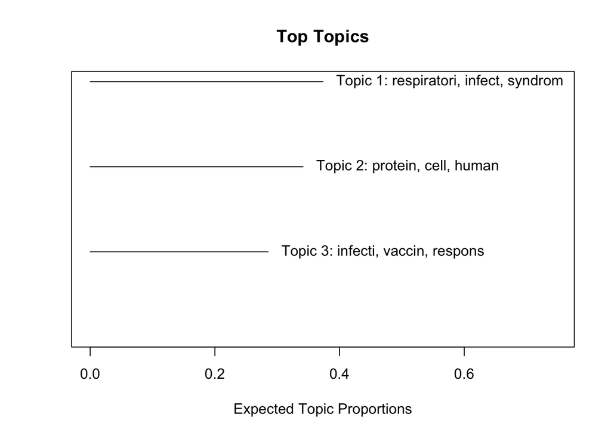

```r
plot.STM(model3, type = "summary")
```

Link to 3 topic visual: https://bl.ocks.org/ihsankahveci/raw/f5935b30892a9217f03e6d0ea8e17d5c/

**Note**: LDAvis may renumber the topics.

Though many of our essential topics appeared at this low level of topics, we decided too much was excluded for us to be able to utilize so few k. We decided to try with 10 topics and compare it to our initial LDA model.

## STM with 10 topics:

```r
model10 <- stm(documents = out$documents,
             vocab = out$vocab,
             data = out$meta,
             init.type = "LDA",
             max.em.its = 20,
             K = 10, verbose = F,
             ngroups = 2, #parelel processing
             seed = 57)
```

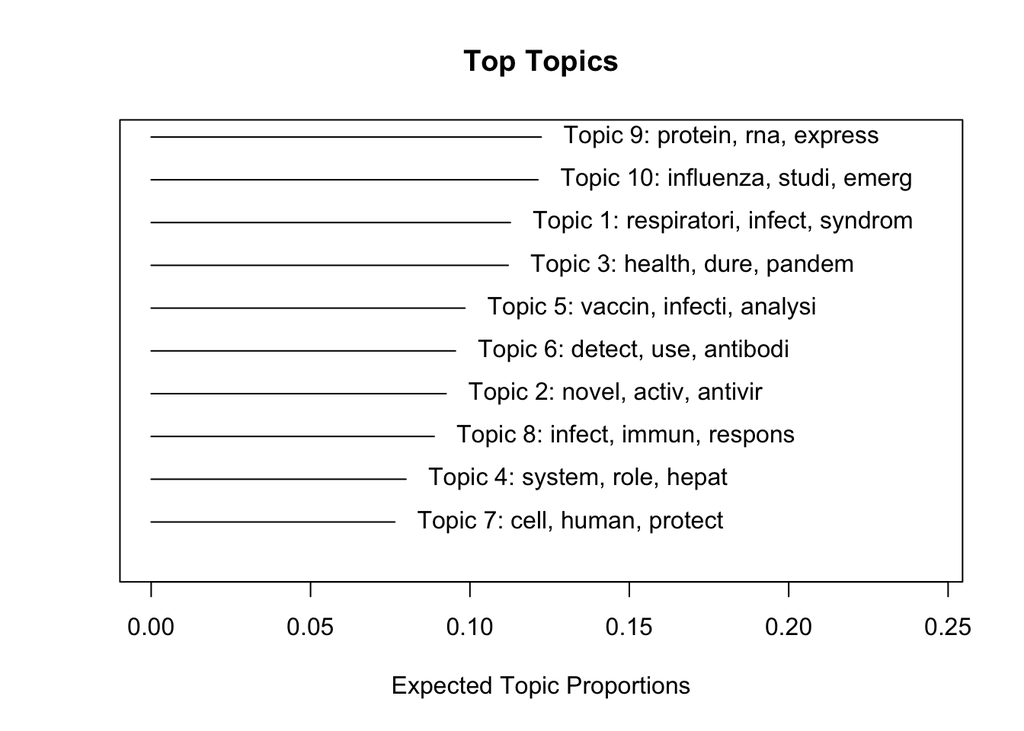

```r
plot.STM(model10, type = "summary")
```

Link to 10 topic visual: https://bl.ocks.org/ihsankahveci/raw/918ac892b5833cb71cd0dec500b1f956/

**Note**: LDAvis may renumber the topics.

Finally, we have reached semantically meaningful 10 topics. Not all of them are very different from each other, the three major clusters are still there but there is an important variation captured too.

# Labeling the topics

This visualization describes the prevalence of the topic within the entire corpus as well as the top three words associated with the topic. As in our earlier example, you may see that there are some topics that seem plausible, but many others that do not seem very coherent or meaningful. The `stm` package has another useful function called `findThoughts` which extracts passages from documents within the corpus that load high on topics specified by the user.

```r
corpus_sub = corpus[-empty_docs] #length must be equal to stm object
```

Getting the most representative documents for topics 1,10,3:

```r
thoughts1 <- findThoughts(model10, texts = texts(corpus_sub), topics=1, n=10)$docs[[1]]
thoughts10 <- findThoughts(model10, texts = texts(corpus_sub), topics=10, n=10)$docs[[1]]
thoughts3 <- findThoughts(model10, texts = texts(corpus_sub), topics=3, n=10)$docs[[1]]
```

Printing the sentences:

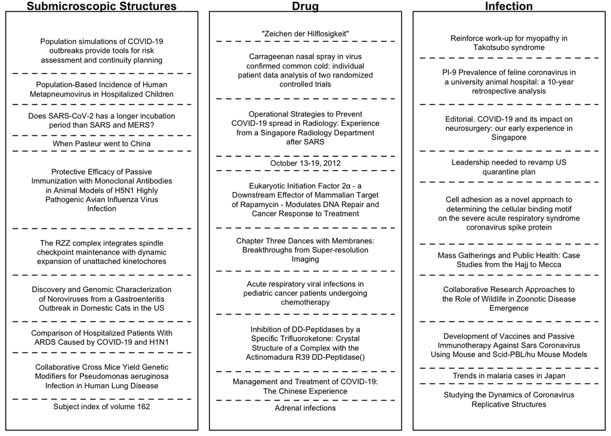

```r
par(mfrow = c(1, 3), mar=c(.5,.5,1,.5))
plotQuote(thoughts1, width=40, text.cex = .8  ,main="Submicroscopic Structures")
plotQuote(thoughts10, width=40, text.cex = .8, main="Drug")
plotQuote(thoughts3, width=40, text.cex = .8, main="Infection")
```